# Pristina TranscriptomicLandscape: Differential Gene Expression Analysis

Alberto Perez-Posada @apposada

09/12/2022

## About

This markdown shows how we performed differential gene expression analysis in *Pristina leidyi* piwi+ cells compared to the rest of cell clusters.

We will do a step-by-step analysis and will later wrap everything into a wrapper function that takes an expression dataset and sample dataset and returns the linear model, the results of the DGE, and a volcano plot object that can be plotted.

## Loading Necessary Packages

```r
require(dplyr)
require(tidyr)
require(apeglm)
require(ggplot2)
require(ggrepel)
require(EnhancedVolcano)
require(edgeR)
require(limma)
```

## Loading necessary dataset

```r
  load("./outputs/rda/01_plei_dataload.rda")
```

# 1: Data exploration. Library size

We will be using the package `limma` (and `edgeR`) to analyse the differential expression of genes in the piwi-positive clusters compared to the rest of the clusters.

The package `limma` has its own methods to take into account library size and normalisation and therefore we will be NOT using the normalised counts we obtained from DESeq2.

We start by remembering the looks of the reads in each cluster of cells in Pristina. For simplicity over the rest of the markdown, we will call this table “`counts`” .

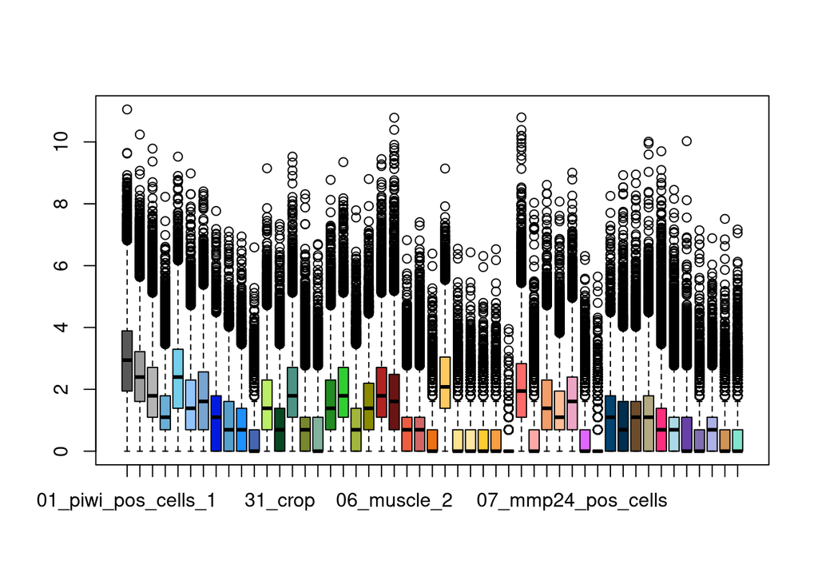

```r
counts <- plei_counts

boxplot(log(counts+1), col = plei_ctypes_col$col)
```

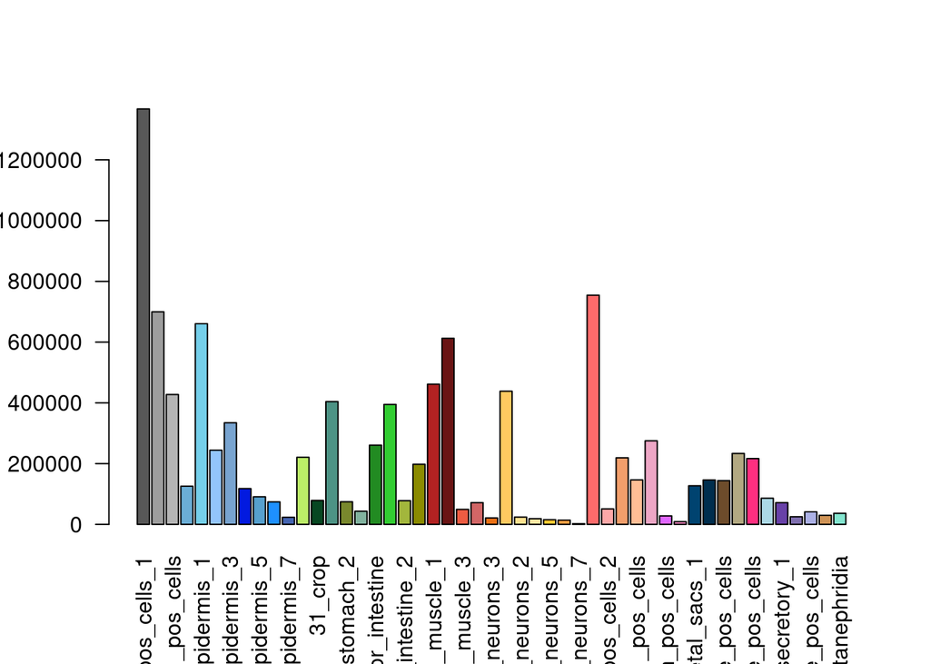

```r
libsize <- as.data.frame(colSums(plei_counts))
colnames(libsize) <- "LibSize"
libsize$id <- as.factor(row.names(libsize))
libsize$color <- plei_ctypes_col$col

barplot(libsize$LibSize,col = libsize$color, names = libsize$id, las = 2)
```

# 2. The sample information

We will create a table with all the information of our “samples” (the cell cluster).

Importantly, one of the columns, labeled **pluripotent**, indicates what are the cell clusters that we want to compare over the others.

```r
samples.info = data.frame(
  sample = as.character(plei_ctypes_col$cluster),
  pluripotent = c(rep("piwi_pos",3),rep("non_piwi",length(plei_ctypes_col$cluster) - 3 ))
)
rownames(samples.info) <- plei_ctypes_col$cluster

head(samples.info)
```

```
##                                            sample pluripotent
## 01_piwi_pos_cells_1           01_piwi_pos_cells_1    piwi_pos
## 02_piwi_pos_cells_2           02_piwi_pos_cells_2    piwi_pos
## 08_nidogen1_pos_cells       08_nidogen1_pos_cells    piwi_pos
## 18_epidermal_progenitors 18_epidermal_progenitors    non_piwi
## 00_epidermis_1                     00_epidermis_1    non_piwi
## 11_epidermis_2                     11_epidermis_2    non_piwi
```

# 3. Filtering the gene expression dataset for DGE

We will create an `edgeR` `DGE` object using our `counts` and `samples.info` data.

```r
 dge <- DGEList(
    counts=counts,
    samples=samples.info,
    group=samples.info$pluripotent
  )
```

`edgeR` has a function that allows to filter by gene expression taking into account library size. Quoting:

“This function implements the filtering strategy that was intuitively described by Chen et al (2016). Roughly speaking, the strategy keeps genes that have at least min.count reads in a worthwhile number samples.More precisely, the filtering keeps genes that have count-per-million (CPM) above k in n samples, where k is determined by min.count and by the sample library sizes and n is determined by the design matrix.”

The output returned is a logical vector indicating which rows to keep in the analysis.

```r
  keep <- filterByExpr(dge)
  dge <- dge[keep,,keep.lib.sizes=FALSE]
```

# 4. The Design Matrix

Next is the creation of the design matrix that can be later passed down to limma to work out a linear model.

```r
design.condition <- model.matrix( ~ samples.info$pluripotent, dge)
# parsing the columns to have prettier names
colnames(design.condition) <- gsub("samples.info[$]pluripotent", "", colnames(design.condition))
colnames(design.condition) <- gsub("samples.info[$]sample", "", colnames(design.condition))
names(attr(design.condition,"contrasts")) <- c("condition")
rownames(design.condition) <- rownames(samples.info)

design.condition
```

```
##                                 (Intercept) piwi_pos
## 01_piwi_pos_cells_1                       1        1
## 02_piwi_pos_cells_2                       1        1
## 08_nidogen1_pos_cells                     1        1
## 18_epidermal_progenitors                  1        0
## 00_epidermis_1                            1        0
## 11_epidermis_2                            1        0
## 13_epidermis_3                            1        0
## 20_epidermis_4                            1        0
## 24_epidermis_5                            1        0
## 25_epidermis_6                            1        0
## 43_epidermis_7                            1        0
## 16_gut_progenitors                        1        0
## 31_crop                                   1        0
## 14_stomach_1                              1        0
## 39_stomach_2                              1        0
## 38_caveolin_pos_cells                     1        0
## 15_anterior_intestine                     1        0
## 09_anterior_mid_intestine_1               1        0
## 28_anterior_mid_intestine_2               1        0
## 19_posterior_intestine                    1        0
## 05_muscle_1                               1        0
## 06_muscle_2                               1        0
## 27_muscle_3                               1        0
## 30_muscle_4                               1        0
## 41_neurons_3                              1        0
## 03_neurons_1                              1        0
## 40_neurons_2                              1        0
## 42_neurons_4                              1        0
## 45_neurons_5                              1        0
## 49_neurons_6                              1        0
## 59_neurons_7                              1        0
## 04_globin_pos_cells_1                     1        0
## 33_globin_pos_cells_2                     1        0
## 10_polycystin_2_pos_cells                 1        0
## 12_polycystin_1_pos_cells                 1        0
## 07_mmp24_pos_cells                        1        0
## 36_fucolectin_pos_cells                   1        0
## 55_pgrn_pos_cells                         1        0
## 21_chaetal_sacs_1                         1        0
## 22_chaetal_sacs_2                         1        0
## 17_lipoxygenase_pos_cells                 1        0
## 23_vigilin_pos_cells                      1        0
## 26_lumbrokinase_pos_cells                 1        0
## 29_carbohydrate_metabolic_cells           1        0
## 34_secretory_1                            1        0
## 44_secretory_2                            1        0
## 32_arginase_pos_cells                     1        0
## 35_ldlrr_pos_cells                        1        0
## 37_metanephridia                          1        0
## attr(,"assign")
## [1] 0 1
## attr(,"contrasts")
## attr(,"contrasts")$condition
## [1] "contr.treatment"
```

# 5. Scaling factors to transform the libraries

We are now ready to run `limma`. The first step is calculating scaling factors to transform the library sizes. The default methods uses trimmed mean of M-values.

```r
dge <- calcNormFactors(dge, method="TMM")
```

# 6. Normalisation of gene expression using VOOM method

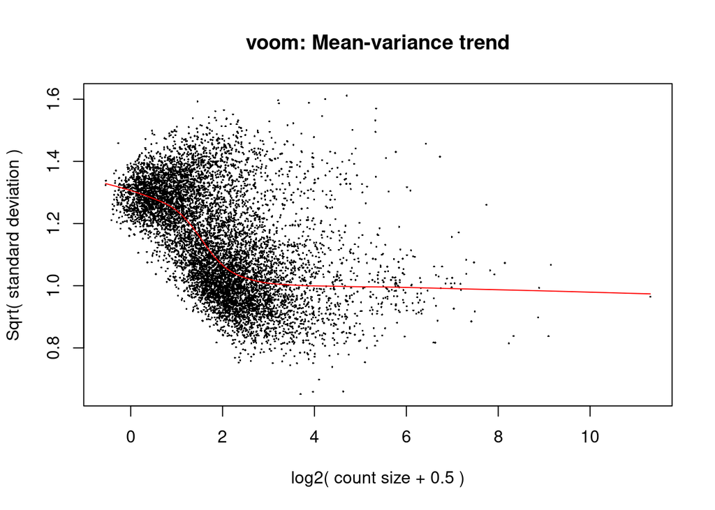

```r
v <- voom(dge, design.condition, plot=TRUE)
```

# 7. Linear Model Fitting and statistics

This expression data is now ready for linear model fitting. The `lmFit` will fit a linear model for each gene given the conditions in the design matrix.

```r
fitv <- lmFit(v, design.condition)
```

From this fitting, the `eBayes` function computes the statistics and log-odds of differential expression, for later ranking the genes in order of evidence for DGE, and appends it to the `fitv` object.

```r
fitv <- eBayes(fitv)
```

The summary of the results here:

```r
sumfit <- summary(decideTests(fitv))
sumfit
```

```
##        (Intercept) piwi_pos
## Down             0       36
## NotSig           0     7477
## Up            8402      889
```

# 8. Results and plotting

The `topTable` retrieves a table of the top-ranked genes. We will use `fdr` as the adjusting (correction) method.

```r
top.res.v <- topTable(fitv, coef=ncol(design.condition),
                        adjust="fdr", sort.by="B",
                        number=Inf)
```

We can tidy up the contents of the top table and add a `rank` column that indicates if a gene is differentially expressed or not.

We will set up a minimum threshold of 1.5 for the logFoldChanges in gene expression and a p-value of 0.01 as what we will consider as significant.

```r
MIN.FC = 1.5
MIN.PV = 0.01
```

And then the column itself:

```r
top.res.v$rank <- ifelse(is.na(top.res.v$P.Value) | is.na(top.res.v$logFC), NA,
                         -log10(top.res.v$P.Value)*top.res.v$logFC *
                           ifelse(top.res.v$P.Value <= MIN.PV & abs(top.res.v$logFC) >= MIN.FC,
                                  ifelse(top.res.v$adj.P.Val <= MIN.PV, 1e4, 1e2), 1))
```

More tidying up based on our criteria. The important column here is `$DGE.padj` that will tell us if a gene is significantly differentially expressed or not based on its adjusted p-value (after correction).

```r
top.res.v$DGE.pval <- as.factor(
  ifelse(top.res.v$P.Value <= MIN.PV & abs(top.res.v$logFC) >= MIN.FC,
           ifelse(top.res.v$logFC >= MIN.FC, "up", "down"), "no-sig") )

top.res.v$DGE.padj <- as.factor(
  ifelse(top.res.v$adj.P.Val <= MIN.PV & abs(top.res.v$logFC) >= MIN.FC,
         ifelse(top.res.v$logFC >= MIN.FC, "UP", "DOWN"), "no-sig") )
```

The number of DEG with and without correction

```r
UPDN <- c(nrow(top.res.v[ top.res.v$DGE.padj == "UP", ]),
          nrow(top.res.v[ top.res.v$DGE.padj == "DOWN", ]))
updn <- c(nrow(top.res.v[ top.res.v$DGE.pval == "up", ]),
          nrow(top.res.v[ top.res.v$DGE.pval == "down", ]))

paste0("WithOUT correction: ", updn, " genes", c(" up"," down"))
```

```
## [1] "WithOUT correction: 767 genes up"  "WithOUT correction: 80 genes down"
```

```r
paste0("With correction: ", UPDN, " genes", c(" up"," down"))
```

```
## [1] "With correction: 513 genes up" "With correction: 3 genes down"
```

To visualise all this information more nicely, a volcano plot from the package `EnhancedVolcano`.

```r
volcanoplot.limma.v <- EnhancedVolcano(
  data.frame(top.res.v), x = 'logFC', y = 'adj.P.Val',
  lab = rownames(top.res.v),
  xlab = bquote(~Log[2]~ 'fold change'),
  ylab = bquote(~-Log[10]~adjusted~italic(P)),
  ylim = c(0, 6),
  pCutoff = MIN.PV, FCcutoff = MIN.FC, pointSize = 1.0, labSize = 2.0,
  title = paste0("Piwi vs non-Piwi"),
  subtitle = 'limma-voom analysis',
  caption = paste0('log2 FC cutoff: ', MIN.FC, '; p-value cutoff: ',
                   MIN.PV, '\nTotal = ', nrow(top.res.v),
                   ' markers  [ ',UPDN[1],'UP, ',UPDN[2],'DOWN ]'),
  legendPosition = 'bottom', legendLabSize = 14, legendIconSize = 5.0,
  drawConnectors = TRUE, widthConnectors = 0.25,
  colConnectors = 'grey30',
  gridlines.major = FALSE,
  gridlines.minor = TRUE,
  col = c("gray","#a2d9a6","darkgray","#4eaf55")
) + coord_flip()
```

And its visualisation:

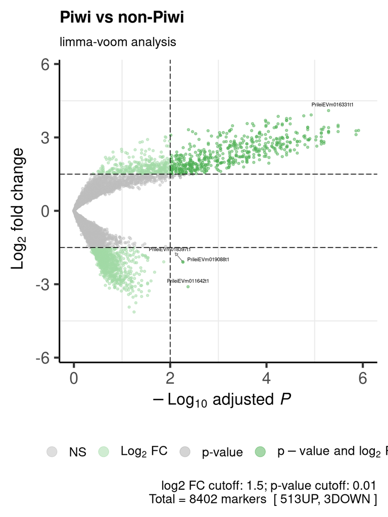

```r
print(volcanoplot.limma.v)
```

We can save the results in a table:

```r
write.table(
  top.res.v[top.res.v$DGE.padj != "no-sig",],
  paste0(
    "./outputs/",
    "plei_piwi_vs_all_DGE.tsv"
  ),
  sep = "\t",
  dec = ".",
  row.names = TRUE,
  quote = FALSE
)
```

## Downstream analyses

These genes can be further analysed by checking their enriched GO terms compared to the set of all genes in pristina, or other group of differentially expressed genes.

```r
source("./code/R_functions/wgcna_igraph_functions/topGO_wrap_function.R")
geneID2GO <- readMappings("./data/04_eggNOGannotation/plei_eggnog_GOs.tsv")

plei_piwi_GO <- getGOs(
  genelist = list(
    piwi_up = rownames(top.res.v[top.res.v$DGE.padj == "UP",])
    ),
  gene_universe = rownames(plei_cpm),
  gene2GO = geneID2GO
)
```

```
## [1] "Starting analysis 1 of 1"
```

The resulting GO terms are seen below. It seems these genes are enriched in GO terms related to gene expression and cell proliferation, as described for other pluripotent lineages in other regenerative animals such as planarians neoblasts.

```r
res_GOs <- plei_piwi_GO$GOtable$piwi_up
res_GOs
```

```
##         GO.ID
## 1  GO:0090304
## 2  GO:0022613
## 3  GO:0006396
## 4  GO:0006139
## 5  GO:0034641
## 6  GO:0046483
## 7  GO:0006725
## 8  GO:0042254
## 9  GO:0016070
## 10 GO:1901360
## 11 GO:0010467
## 12 GO:0016072
## 13 GO:0006364
## 14 GO:0043170
```

[output cut: 78 more lines]

## A wrapper function

We have wrapped everything in a function that can be readily used to retrieve differentially expressed genes from a matrix of gene expression (pre-normalisation), a table of sample information, and a condition to compare against.

```r
limma_wrap <- function(
  counts, samples.info, condition, MIN.PV = 0.05, MIN.FC = 1.5, adjust = "fdr",
  plot = FALSE){
  # counts = plei_counts[,1:2]
  # samples.info <- plei_samples_info[1:2,]
  # condition = "cellcycle_stage"
  # print(paste0("Condition chosen = ",condition))

  samples.info$condition <- samples.info[,colnames(samples.info) == condition ]

  print("Creating DGE objects")
  dge <- DGEList(
    counts=counts,
    samples=samples.info,
    group=samples.info$condition
  )
  dge
  keep <- filterByExpr(dge)
  dge <- dge[keep,,keep.lib.sizes=FALSE]

  # if(ncol(counts) <= 2) {dge <- t(dge)}

  print("Creating model matrix")
  design.condition <- model.matrix( ~ samples.info$condition, dge)
  colnames(design.condition) <- gsub("samples.info[$]condition", "", colnames(design.condition))
  colnames(design.condition) <- gsub("samples.info[$]sample", "", colnames(design.condition))
  names(attr(design.condition,"contrasts")) <- c("condition")
  rownames(design.condition) <- rownames(samples.info)

  print(paste0('The largest library has: ',max(dge$samples$lib.size),' counts'))
  print(paste0('The smallest library has: ',min(dge$samples$lib.size),' counts'))
  print(paste0("That's ", round(max(dge$samples$lib.size)/min(dge$samples$lib.size),1), " times bigger"))


  #ready to run LIMMA
  print("Ready to run limma.")

  print("Calculating factors")
  dge <- calcNormFactors(dge, method="TMM")

  print("voom normalisation")
  v <- voom(dge, design.condition, plot=plot) #it finds more DE genes using qnorm

  print("limma linear model fitting")
  fitv <- lmFit(v, design.condition)
  fitv <- eBayes(fitv)
  sumfit <- summary(decideTests(fitv))

  print("creating results")
  top.res.v <- topTable(fitv, coef=ncol(design.condition),
                        adjust=adjust, sort.by="B",
                        number=Inf)

  top.res.v$rank <- ifelse(is.na(top.res.v$P.Value) | is.na(top.res.v$logFC), NA,
                           -log10(top.res.v$P.Value)*top.res.v$logFC *
                             ifelse(top.res.v$P.Value <= MIN.PV & abs(top.res.v$logFC) >= MIN.FC,
                                    ifelse(top.res.v$adj.P.Val <= MIN.PV, 1e4, 1e2), 1));

  print("adjusting pvalues")
  top.res.v$DGE.pval <- as.factor(
    ifelse(top.res.v$P.Value <= MIN.PV & abs(top.res.v$logFC) >= MIN.FC,
           ifelse(top.res.v$logFC >= MIN.FC, "up", "down"), "no-sig") );

  top.res.v$DGE.padj <- as.factor(
    ifelse(top.res.v$adj.P.Val <= MIN.PV & abs(top.res.v$logFC) >= MIN.FC,
           ifelse(top.res.v$logFC >= MIN.FC, "UP", "DOWN"), "no-sig") );

  UPDN <- c(nrow(top.res.v[ top.res.v$DGE.padj == "UP", ]),
            nrow(top.res.v[ top.res.v$DGE.padj == "DOWN", ]))
  updn <- c(nrow(top.res.v[ top.res.v$DGE.pval == "up", ]),
            nrow(top.res.v[ top.res.v$DGE.pval == "down", ]))


  print("creating plot")
  volcanoplot.limma.v <- EnhancedVolcano(
    data.frame(top.res.v), x = 'logFC', y = 'adj.P.Val',
    lab = rownames(top.res.v),
    xlab = bquote(~Log[2]~ 'fold change'),
    ylab = bquote(~-Log[10]~adjusted~italic(P)),
    ylim = c(0, 6),
    pCutoff = MIN.PV, FCcutoff = MIN.FC, pointSize = 1.0, labSize = 2.0,
    title = paste0("Piwi vs non-Piwi"),
    subtitle = 'limma-voom analysis',
    caption = paste0('log2 FC cutoff: ', MIN.FC, '; p-value cutoff: ',
                     MIN.PV, '\nTotal = ', nrow(top.res.v),
                     ' markers  [ ',UPDN[1],'UP, ',UPDN[2],'DOWN ]'),
    legendPosition = 'bottom', legendLabSize = 14, legendIconSize = 5.0,
    drawConnectors = TRUE, widthConnectors = 0.25,
    colConnectors = 'grey30',
    gridlines.major = FALSE,
    gridlines.minor = TRUE,
    col = c("gray","#a2d9a6","darkgray","#4eaf55")
    # max.overlaps = 10,
  ) + coord_flip()

  if(plot == TRUE){
    print(volcanoplot.limma.v)
  }

  res <- list(
    input_information = samples.info,
    design = design.condition,
    summary_fit = sumfit,
    results = top.res.v,
    volcanoplot = volcanoplot.limma.v
  )

  print("DONE.")


  return(res)

}
```